# TFA exam - Guiding solution

Lars Relund Nielsen

# R - Assignment 1 (40%)

Consider the dataset in the file `jobs.csv` with engine maintenance jobs for a group of ships.

The dataset contains a row for each item used. The columns/variables are:

- `ship`: The ship considered.
- `job_id`: Maintenance job id. A job is a collection of items replaced.
- `job_desc`: Job description.
- `item_id`: Item id.
- `item_name`: Item name.
- `item_quantity`: Number of items used.
- `item_manufaturer`: Item manufacturer.
- `component_id`: Engine component id.
- `component_desc`: Engine component description.
- `done_date`: Date the job finished.
- `year`: Year of done date.
- `days`: Days since the item was last used for maintenance on the ship.

Use the *dplyr* package in *tidyverse* to calculate relevant summary tables (tibbles/data frames) and answer/complete the following questions/tasks.

## Question 1

Find the delimiter used in the csv file and load the file into a tibble/data frame called `dat`.

```r
# load packages
library(tidyverse)
library(skimr)

lines <- read_lines("jobs.csv", n_max = 3)
lines
```

```
## [1] "ship,job_id,job_desc,item_id,item_name,item_quantity,item_manufaturer,component_id,component_desc,done_date,year,days"
## [2] "Ship-20,2379,\"ME Exh. Gas outlet temp. cyl,#1 sensor pocket and wire cable\",601.001.001,\"Thermocouple TC-87-02,  Model: MPT 100K, Type: K, Temp :0-600 'C, Class:B, Tube:\",1,\"CMR KOREA CO.,LTD\",601.001.01,Main Engine,2018-08-14,2018,NA"
## [3] "Ship-21,1899,M.E cylinder no.4 exhaust gas temperature thermocouple replacement,601.001.001,\"Thermocouple TC-87-02,  Model: MPT 100K, Type: K, Temp :0-600 'C, Class:B, Tube:\",1,\"CMR KOREA CO.,LTD\",601.002.04,ME Cylinder Cover No 4,2016-12-20,2016,NA"
```

```r
dat <- read_csv("jobs.csv")
```

It can be seen that a comma (`,`) is used a delimiter. That is, the dataset is loaded using `read_csv`.

## Question 2

Provide a short overview of the data. How many rows are there in the data, what is the number of different ships, and what is the range of dates?

```r
skim(dat)
```

Data summary

| Name | dat |
| --- | --- |
| Number of rows | 3106 |
| Number of columns | 12 |
| _______________________ |  |
| Column type frequency: |  |
| character | 7 |
| Date | 1 |
| numeric | 4 |
| ________________________ |  |
| Group variables | None |

**Variable type: character**

| skim_variable | n_missing | complete_rate | min | max | empty | n_unique | whitespace |
| --- | --- | --- | --- | --- | --- | --- | --- |
| ship | 0 | 1.00 | 6 | 7 | 0 | 9 | 0 |
| job_desc | 51 | 0.98 | 17 | 80 | 0 | 241 | 0 |
| item_id | 0 | 1.00 | 11 | 11 | 0 | 216 | 0 |
| item_name | 0 | 1.00 | 3 | 80 | 0 | 138 | 0 |
| item_manufaturer | 17 | 0.99 | 4 | 35 | 0 | 19 | 0 |
| component_id | 0 | 1.00 | 3 | 10 | 0 | 144 | 0 |
| component_desc | 53 | 0.98 | 9 | 51 | 0 | 214 | 0 |

**Variable type: Date**

| skim_variable | n_missing | complete_rate | min | max | median | n_unique |
| --- | --- | --- | --- | --- | --- | --- |
| done_date | 0 | 1 | 2015-01-24 | 2020-04-21 | 2018-09-20 | 288 |

**Variable type: numeric**

| skim_variable | n_missing | complete_rate | mean | sd | p0 | p25 | p50 | p75 | p100 | hist |
| --- | --- | --- | --- | --- | --- | --- | --- | --- | --- | --- |
| job_id | 0 | 1.00 | 1344.6 | 1157.5 | 1 | 656 | 862 | 2010 | 6791 | ▇▂▁▁▁ |
| item_quantity | 0 | 1.00 | 1.1 | 1.1 | 0 | 1 | 1 | 1 | 32 | ▇▁▁▁▁ |
| year | 0 | 1.00 | 2018.0 | 1.2 | 2015 | 2017 | 2018 | 2019 | 2020 | ▂▅▇▆▂ |
| days | 554 | 0.82 | 61.4 | 167.2 | 0 | 0 | 0 | 20 | 1625 | ▇▁▁▁▁ |

We have a total of 3106 rows/observations for 9 ships over a period from 2015-01-24 to 2020-04-21.

## Question 3

What is the total number of different jobs, number of different jobs per ship, and average number of jobs per ship? Hint: The function `n_distinct` may be used to find distinct values within a group.

```r
res1 <- dat %>%
   distinct(job_id) %>%
   nrow() %>%
   print()
```

```
## [1] 463
```

```r
res2 <- dat %>%
   group_by(ship) %>%
   summarise(jobs = n_distinct(job_id)) %>%
   print()
```

```
## # A tibble: 9 × 2
##   ship     jobs
##   <chr>   <int>
## 1 Ship-10   126
## 2 Ship-11    70
## 3 Ship-12   130
## 4 Ship-13    76
## 5 Ship-14    32
## 6 Ship-19    25
## 7 Ship-20    37
## 8 Ship-21    86
## 9 Ship-9     70
```

```r
res3 <- res2 %>%
   summarise(avg_jobs = mean(jobs)) %>%
   print()
```

```
## # A tibble: 1 × 1
##   avg_jobs
##      <dbl>
## 1     72.4
```

We have a total of 463 jobs, the number of jobs for each ship can be seen using `res2` with and average of 72.44 jobs per ship.

## Question 4

What is the minimum, average, and maximum number of *different* items considered at each job? What is the minimum, average, and maximum number of items used for maintenance at each job?

```r
res1 <- dat %>%
   distinct(job_id, item_id) %>%
   count(job_id) %>%
   summarise(min = min(n), avg = mean(n), max = max(n)) %>%
   print()
```

```
## # A tibble: 1 × 3
##     min   avg   max
##   <int> <dbl> <int>
## 1     1  5.06    27
```

```r
res2 <- dat %>%
   group_by(job_id) %>%
   summarise(n = sum(item_quantity)) %>%
   summarise(min = min(n), avg = mean(n), max = max(n)) %>%
   print()
```

```
## # A tibble: 1 × 3
##     min   avg   max
##   <dbl> <dbl> <dbl>
## 1     0  7.17    53
```

The range and average of unique items considered can be seen using `res1` and the range and average of items used can be seen using `res2`. Note some jobs don’t use the allocated item.

## Question 5

It seems that some items considered in a job are not used anyway. Which ship has most jobs where an item should have been used, but has not (quantity is zero)?

```r
res <- dat %>%
   filter(item_quantity == 0) %>%
   group_by(ship) %>%
   summarise(jobs = n_distinct(job_id)) %>%
   arrange(desc(jobs)) %>%
   print()
```

```
## # A tibble: 7 × 2
##   ship     jobs
##   <chr>   <int>
## 1 Ship-10    84
## 2 Ship-14     9
## 3 Ship-9      8
## 4 Ship-20     4
## 5 Ship-21     3
## 6 Ship-12     2
## 7 Ship-19     1
```

Ship-10 have a lot of jobs where the items scheduled in a job, have not been used.

## Question 6

Which item is the most used one for maintenance?

```r
res <- dat %>%
   group_by(item_id) %>%
   summarize(n = sum(item_quantity), item_name = first(item_name)) %>%
   arrange(desc(n)) %>%
   print()
```

```
## # A tibble: 216 × 3
##    item_id         n item_name
##    <chr>       <dbl> <chr>
##  1 601.003.013   281 Sealing Ring
##  2 601.004.006   144 Piston Ring No. 2 And No. 4
##  3 601.026.128   107 O-Ring
##  4 601.026.052    96 Suction Valve, Compl
##  5 601.026.026    89 Back-Up Ring
##  6 601.003.011    85 Packing
##  7 601.003.007    83 O-Ring  Modified No.5165541-1
##  8 601.026.139    81 Spindle Guide, Complete
##  9 601.004.005    74 Piston Ring No. 1
## 10 601.003.014    72 Gasket
## # … with 206 more rows
```

Item 601.003.013 a Sealing Ring is used most.

# R - Assignment 2 (40%)

Answer this assignment using the *ggplot2* package in *tidyverse* (you may need *dplyr* for preparing the datasets you want to plot). We work with the dataset from Assignment 1, which can be read using:

```r
library(tidyverse)
dat <- read_csv("jobs.csv")
```

## Question 1

For each year and job id, identify the ship the job was done on. Hint: The `first` function may be used to select the first item within a group. Use this to create a visualization showing the number of maintenance jobs for each year with the following features:

- Bars are used for each year.
- Fill colors are used to identify the ship.
- Legends are put at the bottom of the plot.
- Informative figure title and axis titles are given.

Which year had the most jobs?

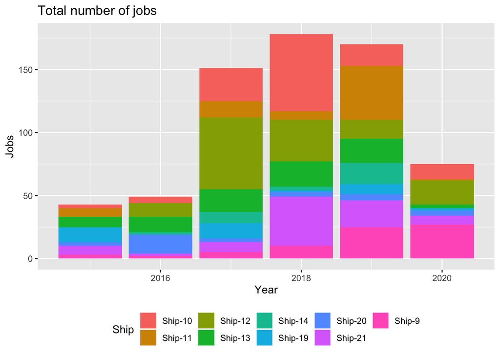

```r
dat %>%
   group_by(year, job_id) %>%
   summarise(ship = first(ship)) %>%
   ggplot(aes(x = year, fill = ship)) +
   geom_bar() +
   labs(title = "Total number of jobs",
    x = "Year",
    y = "Jobs",
    fill = "Ship") +
   theme(legend.position = "bottom")
```

Most jobs where done in 2018.

## Question 2

Create a visualization showing the number of different items used for each ship with the following features:

- The numbers are shown using columns.
- Reorder the columns so they increase along the x-axis.
- Informative figure title and axis titles are given.

Which ship uses most items?

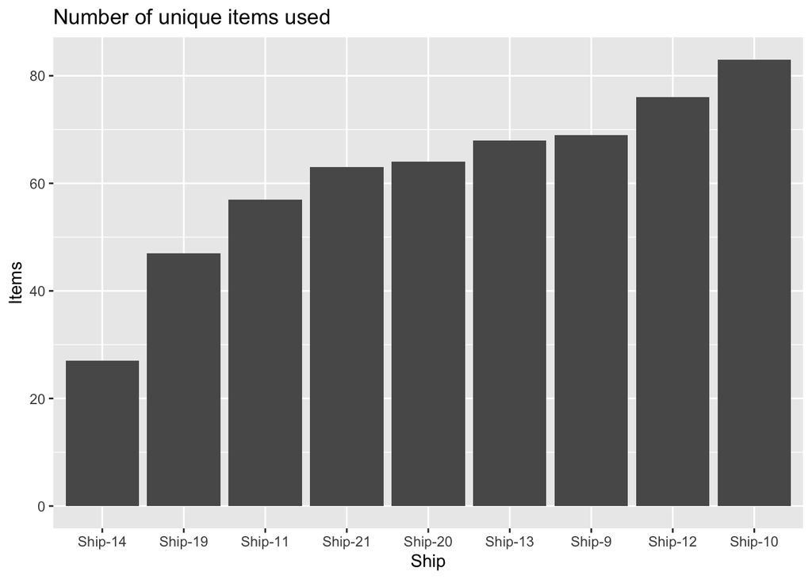

```r
res <- dat %>%
   group_by(ship) %>%
   summarize(n = n_distinct(item_id)) %>%
   arrange(desc(n))
res %>%
   ggplot(aes(x = reorder(ship, n), y = n)) +
   geom_col() +
   labs(title = "Number of unique items used",
    x = "Ship",
    y = "Items") +
   theme(legend.position = "bottom")
```

Most items are used for Ship-10.

## Question 3

Create a visualization showing the number of items used as a function of done date with the following features:

- The numbers are shown using columns with a fixed line width of 1 and a blue color.
- The plot is divided using `ship` (facet). Hint: You may use `scales = "free_y"`.
- Informative figure title and axis titles are given.

Which ship has most items used at a specific date?

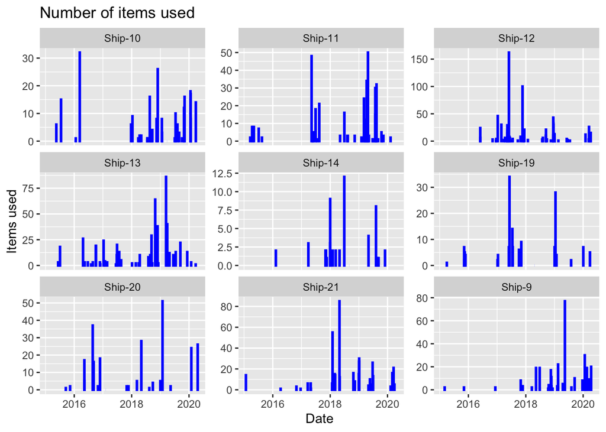

```r
res <- dat %>%
   group_by(ship, done_date) %>%
   summarize(n = sum(item_quantity))
res %>%
   ggplot(aes(x = done_date, y = n)) +
   geom_col(linewidth = 1, color = "blue") +
   facet_wrap(~ ship, scales = "free_y") +
   labs(title = "Number of items used",
    x = "Date",
    y = "Items used")
```

On a specific date must items are used for Ship-12.

## Question 4

Consider two items with id:

```r
items <- c("601.004.006", "601.026.128")
```

Create a visualization showing the variation of demand (item quantity) of each item with the following features:

- A density is plotted for each item with a fixed bandwidth (`bw`) of 1 and transparency (`alpha`) of 0.5.
- Item name is used as fill.
- The plot is divided using `year` (facet).
- Informative figure title and axis titles are given.

Over the years, is it consistent that on average the demand of one of the items is higher than the other?

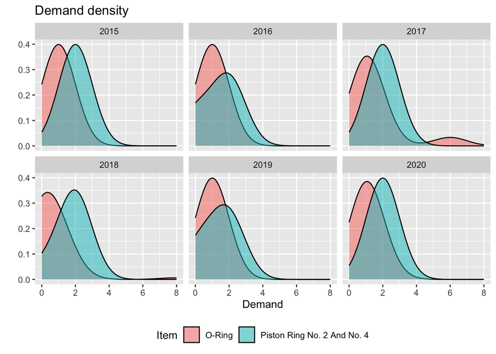

```r
res <- dat %>%
   filter(item_id %in% items)
res %>%
   ggplot(aes(item_quantity, fill = item_name)) +
   geom_density(bw = 1, alpha = 0.5) +
   facet_wrap(~ year) +
   labs(title = "Demand density",
    x = "Demand",
    y = "",
    fill = "Item") +
   theme(legend.position = "bottom")
```

It can be seen that over the years, the demand peak of the Piston Ring is higher that for the O-Ring, i.e. it seems to hold.

## Question 5

Consider two items with id:

```r
items <- c("601.004.006", "601.026.128")
```

Create a visualization showing the variation of days since last used for maintenance given an item with the following features:

- A violin is used to plot days since last used given an item.
- Item name is used as fill.
- Informative figure title and axis titles are given.

Comment on the plot.

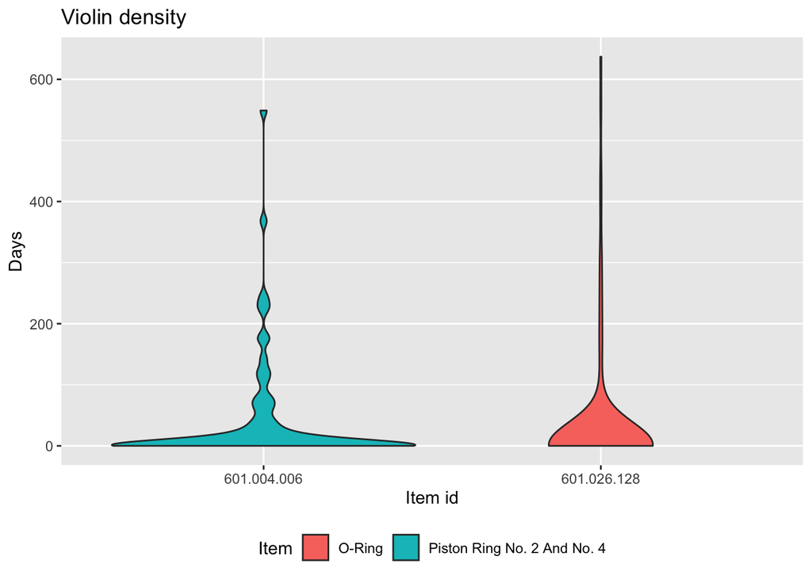

```r
dat %>%
    filter(item_id %in% items) %>%
   ggplot(aes(y = days, x = item_id, fill = item_name)) +
   geom_violin() +
   labs(title = "Violin density",
    x = "Item id",
    y = "Days",
    fill = "Item") +
   theme(legend.position = "bottom")
```

Most often there are less than 100 days between a repeated usage of the item, but there can be over 600 days. The Piston Ring have in general a lower number of days in between than the O-Ring on average.

# R - Assignment 3 (20%)

Create a function `process` with the following features:

- The arguments are:
  - `v`: A vector with numbers (may contain missing values,`NA`s).
  - `find`: A number to search for. Default value is `NULL` indicating not to search for a number.
  - `replace`: A number. If `find` is a number, then replace all occurrences of `find` in the vector with `replace` (if any). Default value is `NULL` indicating not to replace anything.
- The function returns a list with
  - the original vector `v`,
  - the length of `v`,
  - the number of missing values,
  - if find is a number, the number of times the number is found, and
  - if replace is a number, the new vector with the replaced numbers.
- Document your function.

```r
#' Process a vector
#'
#' @param v The vector.
#' @param find A number to search for. Default value is `NULL` indicating not to
#'        search for a number.
#' @param replace A number. If `find` is a number then replace all these numbers
#'        with `replace`. Default value is `NULL` indicating not to replace anything.
#' @return A list with the processed vector and some info.
process <- function(v, find = NULL, replace = NULL) {
   lst <-list(original = v, length = length(v), missing = sum(is.na(v)))
   if (!is.null(find)) {
      idx <- which(v == find)
      lst$found <- length(idx)
      if (!is.null(replace)) {
         v[idx] <- replace
         lst$new <- v
      }
   }
   return(lst)
}
v <- c(8, 19, -2, 8, NA, 12, 9, 23, NA, -34)
process(v)
```

```
## $original
##  [1]   8  19  -2   8  NA  12   9  23  NA -34
##
## $length
## [1] 10
##
## $missing
## [1] 2
```

```r
process(v, find = 1)
```

```
## $original
##  [1]   8  19  -2   8  NA  12   9  23  NA -34
##
## $length
## [1] 10
##
## $missing
## [1] 2
##
## $found
## [1] 0
```

```r
process(v, find = 8)
```

```
## $original
##  [1]   8  19  -2   8  NA  12   9  23  NA -34
##
## $length
## [1] 10
##
## $missing
## [1] 2
##
## $found
## [1] 2
```

```r
process(v, find = 8, replace = 5)
```

```
## $original
##  [1]   8  19  -2   8  NA  12   9  23  NA -34
##
## $length
## [1] 10
##
## $missing
## [1] 2
##
## $found
## [1] 2
##
## $new
##  [1]   5  19  -2   5  NA  12   9  23  NA -34
```